# Huge_Anderson copie

## Andreasen Huge

### Discret time calibration

The calibration technique presented in the paper is described of two main steps:

- Calibration of an arbitrage free surface of European call prices.
- Derivation of the local volatility function from this call surface.

**Assume in the following that the short rate, $r$, is equal to zero as in the Notebook.**

###### Dupire’s forward PDE

The first part is based in a finite difference discretisation of the Dupire partial differential equation (PDE) for the value $C(T,K)$ of an European call option on a non-dividend paying stock, when the spot price is $S$, the volatility is $\sigma(T,K)$ and the maturity is $T$, is

\begin{equation} \frac{\partial C}{\partial T}(T,K) = \frac{1}{2}\sigma^2(T,K)K^2 \frac{\partial^2 C}{\partial K^2}(T,K) \end{equation}

With initial condition

\begin{equation} C(t,s;0,K) = max(s-K,0) \end{equation}

The second part consists of evaluating the finite difference approximation of the corresponding Dupire formula for the local volatility function: \begin{equation} \sigma^2(T,K) = \frac{\frac{\partial C}{\partial T}(t,s,T,K)}{\frac{1}{2}K^2 \frac{\partial^2 C}{\partial K^2}(t,s,T,K)} \end{equation}

#### Building Grid

We denote the maximum values of $K$, and $t$ as $K_{max}$, and $T_{max} = \tau$ (the maturity), and the minimum values as $K_{min}$, and $T_{min}= 0$. We denote by $C^n_{i, j}= C(K_i, T_j)$ the value of an option at time $T_j$ when the strike price is $K_i$. We use $m+ 1$points for the strike price, $n+1$points for the maturity. For convenience, sometimes we write simply $C(K_i, T_j)$ for $C^n_{i, j}$.

A non-uniform set of grid points for the time domain $[0,\tau]$ and a uniform grid for $K$ can be constructed as

\begin{align*} &K_i = K_{min} + i\times \Delta K \quad i=0,1,\dots, m \quad \Delta K = \frac{K_{max}-K_{min}}{m} \\ &0=T_0 < T_1 < \dots < T_n = \tau \quad \Delta T_{j} = T_j-T_{j-1}\quad j=1,\dots,n \end{align*}

#### Boundary Condition

When we come to solving a PDE numerically we must specify the solution value at the extremes of the region. In our specific pricing problem this means that we have to apply the boundary conditions to the lower boundary $K_{min}$ and the upper boundary boundary $K_{max}$, steem from a look at the payoff function for an European call given in terms of the strike level. It seems reasonable to use Neumann conditions on the second order derivatives at the boundaries of the spatial domain: $$ \frac{\partial^2 C(K_{min},T)}{\partial K^2} = \frac{\partial^2 C(K_{max},T)}{\partial K^2} = 0 $$

Almost all common contracts have this property. The finite-difference representation is

$$ C_{m,j} = 2 C_{m-1,j} - C_{m-2,j} $$

### The Fully Implicit Method

Our goal is to solve the well known Dupire PDE. We need to keep in mind that the Andersean-Huge algorithm uses the Dupire forward PDE for option price to recursively generate option prices for expiration $T+\Delta_{T}$ given the prices for expiration $T$.

\begin{equation} \frac{\partial C}{\partial T}(T,K) - \frac{1}{2}\sigma^2(T,K)K^2 \frac{\partial^2 C}{\partial K^2}(T,K) = 0 \end{equation}

To solve this equation, let us discretise the space of $T$ and $K$. In other words, we solve the problem for each points $(K_i,T_j)$. We make the following substitutions and group the factors:

\begin{align} &\frac{\partial}{\partial T} C(T,K) \longrightarrow \frac{C_{i,j}-C_{i,j-1}}{\Delta T_{j}} \\ &\frac{\partial^2}{\partial K^2} C(T,K) \longrightarrow \frac{C_{i+1,j}- 2 C_{i,j}+C_{i-1,j}}{\Delta K^2} \end{align}

where the still unknown local volatility function, $\sigma(T,K)$, is replaced by proxy functions: $\vartheta_{j}(K)$, for each maturity level in the observed data set:

$$ \quad (K_{ij},T_j)_{ij=1,\dots,I_j,j=1,\dots n} $$

$I_j$ is the total number of observed strike levels for the given maturity. The proxy volatility functions are formed as **piecewise constant functions** for a grid of user-defined equidistant strike levels K:

\begin{equation} \vartheta_{j}(K) =\begin{cases} a_1, & \text{if $K \leq b_1$}.\\ a_{ij}, & \text{if $b_{ij-1}<K \leq b_{ij}$} \quad ij = 2,\dots I_j-1 \\ a_{I_j} & \text{if $b_{I_j-1}<K$}. \end{cases} \end{equation}

where the $b_{ij}$’s are given as the mid-points between the observed strike levels for the given maturity: $$ \quad b_{ij} = K_{ij} + \frac{K_{ij+1}-K_{ij}}{2}, \quad ij = 2,\dots I_j-1 $$

With these subsitutions we can write Dupire PDE in the form :

\begin{equation} \frac{C_{i,j}-C_{i,j-1}}{\Delta T_{j}} - \frac{1}{2} \vartheta_{j}(K_i)^2K^2 \frac{C_{i+1,j}- 2 C_{i,j}+C_{i-1,j}}{\Delta K^2} = 0 \quad j=1,\dots,n, \quad i=1,\dots, m-1 \end{equation}

Now let's rewrite the finite difference equation putting the term at the time step $j-1$ on the left side of the equal sign

\begin{align} C_{i,j-1} &= -\frac{1}{2}\vartheta_{j}(K_i)^2K_i^2 \frac{\Delta T_{j}}{\Delta K^2}C_{i+1,j} + \vartheta_{j}(K_i)^2K_i^2 \frac{\Delta T_{j}}{\Delta K^2}C_{i,j} - \frac{1}{2}\vartheta_{j}(K_i)^2K_i^2 \frac{\Delta T_{j}}{\Delta K^2}C_{i+1,j}+ C_{i,j} \notag\\ &= -\frac{1}{2}\vartheta_{j}(K_i)^2K_i^2 \frac{\Delta T_{j}}{\Delta K^2}C_{i+1,j} + (1+\vartheta_{j}(K_i)^2K_i^2 \frac{\Delta T_{j}}{\Delta K^2})C_{i,j} - \frac{1}{2}\vartheta_{j}(K_i)^2K_i^2 \frac{\Delta T_{j}}{\Delta K^2}C_{i+1,j}\notag\\ &= \left[1-\frac{1}{2} \Delta T_{j}\vartheta_{j}(K_i)^2K_i^2 \delta_{KK}\right]C_{i,j} \end{align}

where $\delta_{KK}$ is the central dierence operator given by: \begin{equation} \delta_{yy}f(x_j,y_i) =\frac{1}{\Delta y^2}(f(x_j,y_{i+1})-2f(x_j,y_i)+f(x_j,y_{i-1})) \end{equation}

The theoretical call prices: $(C(T_{j},K_{i},\vartheta_{j}(K_i))_{i=0,\dots,m}$ for time-to-maturity $T_{j}$ is calculated by one time step in the implicit finite dierence method. Hence, by solving a system of linear equations:

$$ \quad A_{j}C(T_{j},{\bf K}) = C(T_{j-1},{\bf K}) $$

where $C(T_{0},{\bf K})$ is given by the initial condition and $A_{j}$ is the tridiagonal

\begin{equation} \begin{bmatrix} 1 & 0 & 0 & 0 & \cdots & 0 \\ -z_1^j & 1+2z_1^j & -z_1^j & 0 & \cdots & 0 \\ 0 & -z_2^j & 1+2z_2^j & -z_2^j & \cdots & 0 \\ \vdots & & \ddots & \ddots & \ddots & \vdots \\ \vdots & \vdots & 0 & -z_{m-1}^j & 1+2z_{m-1}^j & -z_{m-1}^j & \\ 0 & \cdots & & 0 & 0 & 1 \end{bmatrix} \end{equation}

where the coecients $z_i^j$ is given by: $$ \quad z_i^j = \frac{1}{2}\vartheta_{j}(K_i)^2K_i^2 \frac{\Delta T_{j}}{\Delta K^2} \quad i = 1,\dots m-1 $$

Then the complet system of linear equations is :

\begin{equation} \begin{bmatrix} 1 & 0 & 0 & 0 & \cdots & 0 \\ -z_1^j & 1+2z_1^j & -z_1^j & 0 & \cdots & 0 \\ 0 & -z_2^j & 1+2z_2^j & -z_2^j & \cdots & 0 \\ \vdots & & \ddots & \ddots & \ddots & \vdots \\ \vdots & \vdots & 0 & -z_{m-1}^j & 1+2z_{m-1}^j & -z_{m-1}^j & \\ 0 & \cdots & & 0 & 0 & 1 \end{bmatrix} \cdot \left[ \begin{array}{c} C_{0,j+1} \\ C_{1,j+1} \\ C_{2,j+1} \\ \vdots \\ C_{m-1,j+1}\\ C_{m,j+1} \end{array} \right] = \left[\begin{array}{c} C_{0,j} \\ C_{1,j} \\C_{2,j} \\ \vdots \\ C_{m-1,j}\\ C_{m,j} \end{array} \right] \end{equation}

### The volatility proxy’s

There is one problem in this solution: we do not know the theoretical $\vartheta_{j}(K)$ (we only have the observed one, used to find the observed call prices with BS). Therefore, we need to estimate it. To do so, let us assume we have $I_j$ call prices from the market for the expiration $T_{j}$ and assume $\vartheta_{j}(K)$ depends on $I_j$ parameters. We need to fit these parameters so that the option prices generated by the previous time (starting with the smallest, $T_{0}$, working its way up to $T_{n}$), $C^{model}(T_{j},{\bf K}) = A_{j}^{-1}C^{model}(T_{j-1},{\bf K})$, for the observed $I_j$ strikes match the observed prices, $C^{observed}$. In other words, we need to minimise the sum:

\begin{aligned} \min_{\vartheta_{j}(K)} & \sum_{ij=1}^{I_j} \left( {\frac{C^{observed}(T_{j},K_{ij})-C^{model}(T_{j},K_{ij},\vartheta_{j}(K_{ij}))}{w_{ij}}}\right)^2 \quad w_{ij} = \frac{\partial C}{\partial \sigma^{imp}}(T_{j},K_{ij}) \end{aligned}

The weights $w_{ij}$ is given by the greek vega in the Black-Scholes model. We can calibrate volatility proxys $\vartheta_{j}(\cdot)$ using a nonlinear least squares optimization procedure (Levenberg-Marquardt algorithm) with initial guess: $\vartheta_{j}^{ini}(\cdot)$, which is given by the implied volatilities observed in the market.

### Deriving the call surface

The theoretical call prices $C(T_{j},{\bf K})$ and the piecewise constant volatility proxy's $\vartheta_{j}(K)$ are given for all the observed time-to-maturities: $(T_j)_{j=1,\dots n}$ after the calibration has been carried out as described in the previous section. The complete surface of calibrated European call prices can then be obtained by interpolating between the observed maturities by using the implicit finite difference solver. Andreasen and Huge propose to fill the gaps between the observed maturities by stepping directly from $T_{j-1}$ to each of the time points $\tau$ in the interval ($T_{j-1},T_{j}$). In practice, this is done by solving the equation below:

\begin{align} C_{i,j-1} &= \left[1-\frac{1}{2} (T_{l}-T_{i-1})\vartheta_{j}(K_i)^2K_i^2 \delta_{KK}\right]C_{i,j} \quad T_{l} \in(T_{j-1},T_{j}) \end{align}

**Figure 1.1**

[figure not shown]

Figure 1.1 illustrates this procedure.

### Deriving the local volatility surface

The fnal part of the method is to derive the actual local volatility function $\sigma^{local}(K_{i},T_{j})$ from the surface of call prices calibrated by the technique presented in the previous sections. As an entire surface of call prices is now available, this parameter can be determined from a finite difference discretsation of the Dupire formula: \begin{equation} \sigma^{local}(K_{i},T_{j}) = \sqrt{\frac{\frac{C(K_{i},T_{j+1})-C(K_{i},T_{j-1})}{T_{j+1}-T_{j-1}}}{\frac{1}{2}K_{i}^2 \frac{C(K_{i+1},T_{j})-2C(K_{i},T_{j})+C(K_{i-1},T_{j})}{(K_{i}-K_{i-1})(K_{i+1}-K_{i})}}} \quad j=1,\dots,n-1, \quad i=1,\dots, m-1 \end{equation}

```python
import pandas as pd
import numpy as np
from scipy.optimize import minimize, Bounds
from Utils_ import *
import scipy.optimize as opt
from mpl_toolkits import mplot3d
import matplotlib.pyplot as plt
```

```python
# We do data processing, i.e. cut the first and last row of implied_vol_rational, they belong to the lower and upper boundary of call option
# then,  we cut the first maturity column(too short), even though we have the calibrated volatilities
vol_implicit_cut_boundary = vol_implicit[1:-1]
vol_implicit_cut_short_mat = vol_implicit_cut_boundary[:,1:]
tt_cut_short_mat = tt[1:]
```

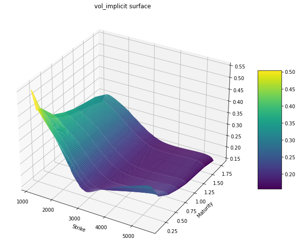

```python
fig = plt.figure(figsize=(12,9))
ax = plt.axes(projection='3d')
X,Y = np.meshgrid(K[1:-1], tt_cut_short_mat)
surf = ax.plot_surface(X, Y, vol_implicit_cut_short_mat.T, rstride=1, cstride=1,
                cmap='viridis', edgecolor='none')
ax.set_title('vol_implicit surface')
ax.set_xlabel("Strike")
ax.set_ylabel("Maturity")
fig.colorbar(surf, shrink=0.5, aspect=5)
plt.show()
```

```python
# Compare the model generated implied volatilities and market observed implied volatilities
implied_vol_observed = np.array(df.iloc[:,1:])
implied_vol_model = implied_volBS_rational(result_C,S0,r,K,T)
implied_vol_interpolation = np.zeros((lenk, lent))

for j in range(lent):
    index = np.where(implied_vol_observed[:,j]!=0)
    implied_vol_interpolation[:,j][index] = implied_vol_model[:,j][index]
```

```python
difference = implied_vol_interpolation - implied_vol_observed
mse = np.sqrt(np.mean(difference[np.nonzero(difference)]**2))
print("mean square root error: {}".format(mse))
```

```
mean square root error: 0.0001563436054332029
```

#### Reference

1. Andreasen, Jesper and Huge, Brian (2011). Volatility interpolation. Risk Magazine, March, 76–79.
2. PhD Thesis Computational Finance - on the search for performance. Lykke Rasmussen.
3. Rasmussen, Lykke (2012). Calibrating the Local Volatility Model - an implicit approach. Master’s thesis, University of Copenhagen.
4. Bruno Dupire (1994). "Pricing with a Smile". Risk.
5. Paul Wilmott on Quantitative Finance, 3 Volume Set, 2nd Edition